# data_exploration-in_class

```python
import pandas as pd
import matplotlib.pyplot as plt
import seaborn as sns

%matplotlib inline

data = pd.read_csv('student_dropout.csv')
data.head()
```

|  | Marital status | Application mode | Application order | Course | Daytime/evening attendance | Previous qualification | Nacionality | Mother's qualification | Father's qualification | Mother's occupation | ... | Curricular units 2nd sem (credited) | Curricular units 2nd sem (enrolled) | Curricular units 2nd sem (evaluations) | Curricular units 2nd sem (approved) | Curricular units 2nd sem (grade) | Curricular units 2nd sem (without evaluations) | Unemployment rate | Inflation rate | GDP | Target |
| --- | --- | --- | --- | --- | --- | --- | --- | --- | --- | --- | --- | --- | --- | --- | --- | --- | --- | --- | --- | --- | --- |
| 0 | 1 | 8 | 5 | 2 | 1 | 1 | 1 | 13 | 10 | 6 | ... | 0 | 0 | 0 | 0 | 0.000000 | 0 | 10.8 | 1.4 | 1.74 | Dropout |
| 1 | 1 | 6 | 1 | 11 | 1 | 1 | 1 | 1 | 3 | 4 | ... | 0 | 6 | 6 | 6 | 13.666667 | 0 | 13.9 | -0.3 | 0.79 | Graduate |
| 2 | 1 | 1 | 5 | 5 | 1 | 1 | 1 | 22 | 27 | 10 | ... | 0 | 6 | 0 | 0 | 0.000000 | 0 | 10.8 | 1.4 | 1.74 | Dropout |
| 3 | 1 | 8 | 2 | 15 | 1 | 1 | 1 | 23 | 27 | 6 | ... | 0 | 6 | 10 | 5 | 12.400000 | 0 | 9.4 | -0.8 | -3.12 | Graduate |
| 4 | 2 | 12 | 1 | 3 | 0 | 1 | 1 | 22 | 28 | 10 | ... | 0 | 6 | 6 | 6 | 13.000000 | 0 | 13.9 | -0.3 | 0.79 | Graduate |

5 rows × 35 columns

```python
data.tail()
```

|  | Marital status | Application mode | Application order | Course | Daytime/evening attendance | Previous qualification | Nacionality | Mother's qualification | Father's qualification | Mother's occupation | ... | Curricular units 2nd sem (credited) | Curricular units 2nd sem (enrolled) | Curricular units 2nd sem (evaluations) | Curricular units 2nd sem (approved) | Curricular units 2nd sem (grade) | Curricular units 2nd sem (without evaluations) | Unemployment rate | Inflation rate | GDP | Target |
| --- | --- | --- | --- | --- | --- | --- | --- | --- | --- | --- | --- | --- | --- | --- | --- | --- | --- | --- | --- | --- | --- |
| 4419 | 1 | 1 | 6 | 15 | 1 | 1 | 1 | 1 | 1 | 6 | ... | 0 | 6 | 8 | 5 | 12.666667 | 0 | 15.5 | 2.8 | -4.06 | Graduate |
| 4420 | 1 | 1 | 2 | 15 | 1 | 1 | 19 | 1 | 1 | 10 | ... | 0 | 6 | 6 | 2 | 11.000000 | 0 | 11.1 | 0.6 | 2.02 | Dropout |
| 4421 | 1 | 1 | 1 | 12 | 1 | 1 | 1 | 22 | 27 | 10 | ... | 0 | 8 | 9 | 1 | 13.500000 | 0 | 13.9 | -0.3 | 0.79 | Dropout |
| 4422 | 1 | 1 | 1 | 9 | 1 | 1 | 1 | 22 | 27 | 8 | ... | 0 | 5 | 6 | 5 | 12.000000 | 0 | 9.4 | -0.8 | -3.12 | Graduate |
| 4423 | 1 | 5 | 1 | 15 | 1 | 1 | 9 | 23 | 27 | 6 | ... | 0 | 6 | 6 | 6 | 13.000000 | 0 | 12.7 | 3.7 | -1.70 | Graduate |

5 rows × 35 columns

```python
data.info()
```

```
<class 'pandas.core.frame.DataFrame'>
RangeIndex: 4424 entries, 0 to 4423
Data columns (total 35 columns):
 #   Column                                          Non-Null Count  Dtype
---  ------                                          --------------  -----
 0   Marital status                                  4424 non-null   int64
 1   Application mode                                4424 non-null   int64
 2   Application order                               4424 non-null   int64
 3   Course                                          4424 non-null   int64
 4   Daytime/evening attendance                      4424 non-null   int64
 5   Previous qualification                          4424 non-null   int64
 6   Nationality                                     4424 non-null   int64
 7   Mother's qualification                          4424 non-null   int64
 8   Father's qualification                          4424 non-null   int64
 9   Mother's occupation                             4424 non-null   int64
```

[output cut: 27 more lines]

The dataset has 4,424 samples, and 35 attributes (29 integer, 5 float, and 1 object)  
No variable column has null/missing values

```python
col_names = data.columns.tolist()
print("Column names:")
print(col_names)
print("\nSample data:")
data.head()
```

```
Column names:
['Marital status', 'Application mode', 'Application order', 'Course', 'Daytime/evening attendance', 'Previous qualification', 'Nationality', "Mother's qualification", "Father's qualification", "Mother's occupation", "Father's occupation", 'Displaced', 'Educational special needs', 'Debtor', 'Tuition …

Sample data:
```

|  | Marital status | Application mode | Application order | Course | Daytime/evening attendance | Previous qualification | Nationality | Mother's qualification | Father's qualification | Mother's occupation | ... | Curricular units 2nd sem (credited) | Curricular units 2nd sem (enrolled) | Curricular units 2nd sem (evaluations) | Curricular units 2nd sem (approved) | Curricular units 2nd sem (grade) | Curricular units 2nd sem (without evaluations) | Unemployment rate | Inflation rate | GDP | Target |
| --- | --- | --- | --- | --- | --- | --- | --- | --- | --- | --- | --- | --- | --- | --- | --- | --- | --- | --- | --- | --- | --- |
| 0 | 1 | 8 | 5 | 2 | 1 | 1 | 1 | 13 | 10 | 6 | ... | 0 | 0 | 0 | 0 | 0.000000 | 0 | 10.8 | 1.4 | 1.74 | Dropout |
| 1 | 1 | 6 | 1 | 11 | 1 | 1 | 1 | 1 | 3 | 4 | ... | 0 | 6 | 6 | 6 | 13.666667 | 0 | 13.9 | -0.3 | 0.79 | Graduate |
| 2 | 1 | 1 | 5 | 5 | 1 | 1 | 1 | 22 | 27 | 10 | ... | 0 | 6 | 0 | 0 | 0.000000 | 0 | 10.8 | 1.4 | 1.74 | Dropout |
| 3 | 1 | 8 | 2 | 15 | 1 | 1 | 1 | 23 | 27 | 6 | ... | 0 | 6 | 10 | 5 | 12.400000 | 0 | 9.4 | -0.8 | -3.12 | Graduate |
| 4 | 2 | 12 | 1 | 3 | 0 | 1 | 1 | 22 | 28 | 10 | ... | 0 | 6 | 6 | 6 | 13.000000 | 0 | 13.9 | -0.3 | 0.79 | Graduate |

5 rows × 35 columns

```python
# renaming column name from 'Nacionality' to 'Nationality'
st_drp = data
st_drp = data.rename(columns={'Nacionality': 'Nationality'})
```

```python
st_drp.dtypes
```

```
Marital status                                      int64
Application mode                                    int64
Application order                                   int64
Course                                              int64
Daytime/evening attendance                          int64
Previous qualification                              int64
Nationality                                         int64
Mother's qualification                              int64
Father's qualification                              int64
Mother's occupation                                 int64
Father's occupation                                 int64
Displaced                                           int64
Educational special needs                           int64
Debtor                                              int64
Tuition fees up to date                             int64
Gender                                              int64
Scholarship holder                                  int64
Age at enrollment                                   int64
International                                       int64
Curricular units 1st sem (credited)                 int64
Curricular units 1st sem (enrolled)                 int64
Curricular units 1st sem (evaluations)              int64
Curricular units 1st sem (approved)                 int64
Curricular units 1st sem (grade)                  float64
Curricular units 1st sem (without evaluations)      int64
Curricular units 2nd sem (credited)                 int64
Curricular units 2nd sem (enrolled)                 int64
Curricular units 2nd sem (evaluations)              int64
Curricular units 2nd sem (approved)                 int64
Curricular units 2nd sem (grade)                  float64
Curricular units 2nd sem (without evaluations)      int64
Unemployment rate                                 float64
Inflation rate                                    float64
GDP                                               float64
Target                                             object
dtype: object
```

```python
st_drp.isnull().any()
```

```
Marital status                                    False
Application mode                                  False
Application order                                 False
Course                                            False
Daytime/evening attendance                        False
Previous qualification                            False
Nationality                                       False
Mother's qualification                            False
Father's qualification                            False
Mother's occupation                               False
Father's occupation                               False
Displaced                                         False
Educational special needs                         False
Debtor                                            False
Tuition fees up to date                           False
Gender                                            False
Scholarship holder                                False
Age at enrollment                                 False
International                                     False
Curricular units 1st sem (credited)               False
Curricular units 1st sem (enrolled)               False
Curricular units 1st sem (evaluations)            False
Curricular units 1st sem (approved)               False
Curricular units 1st sem (grade)                  False
Curricular units 1st sem (without evaluations)    False
Curricular units 2nd sem (credited)               False
Curricular units 2nd sem (enrolled)               False
Curricular units 2nd sem (evaluations)            False
Curricular units 2nd sem (approved)               False
Curricular units 2nd sem (grade)                  False
Curricular units 2nd sem (without evaluations)    False
Unemployment rate                                 False
Inflation rate                                    False
GDP                                               False
Target                                            False
dtype: bool
```

```python
# Number of records and features
st_drp.shape
```

```
(4424, 35)
```

```python
status = st_drp.groupby('Target')
status.mean()
st_drp['Target'].value_counts()
```

```
Target
Graduate    2209
Dropout     1421
Enrolled     794
Name: count, dtype: int64
```

```python
st_drp.describe()
```

|  | Marital status | Application mode | Application order | Course | Daytime/evening attendance | Previous qualification | Nationality | Mother's qualification | Father's qualification | Mother's occupation | ... | Curricular units 1st sem (without evaluations) | Curricular units 2nd sem (credited) | Curricular units 2nd sem (enrolled) | Curricular units 2nd sem (evaluations) | Curricular units 2nd sem (approved) | Curricular units 2nd sem (grade) | Curricular units 2nd sem (without evaluations) | Unemployment rate | Inflation rate | GDP |
| --- | --- | --- | --- | --- | --- | --- | --- | --- | --- | --- | --- | --- | --- | --- | --- | --- | --- | --- | --- | --- | --- |
| count | 4424.000000 | 4424.000000 | 4424.000000 | 4424.000000 | 4424.000000 | 4424.000000 | 4424.000000 | 4424.000000 | 4424.000000 | 4424.000000 | ... | 4424.000000 | 4424.000000 | 4424.000000 | 4424.000000 | 4424.000000 | 4424.000000 | 4424.000000 | 4424.000000 | 4424.000000 | 4424.000000 |
| mean | 1.178571 | 6.886980 | 1.727848 | 9.899186 | 0.890823 | 2.531420 | 1.254521 | 12.322107 | 16.455244 | 7.317812 | ... | 0.137658 | 0.541817 | 6.232143 | 8.063291 | 4.435805 | 10.230206 | 0.150316 | 11.566139 | 1.228029 | 0.001969 |
| std | 0.605747 | 5.298964 | 1.313793 | 4.331792 | 0.311897 | 3.963707 | 1.748447 | 9.026251 | 11.044800 | 3.997828 | ... | 0.690880 | 1.918546 | 2.195951 | 3.947951 | 3.014764 | 5.210808 | 0.753774 | 2.663850 | 1.382711 | 2.269935 |
| min | 1.000000 | 1.000000 | 0.000000 | 1.000000 | 0.000000 | 1.000000 | 1.000000 | 1.000000 | 1.000000 | 1.000000 | ... | 0.000000 | 0.000000 | 0.000000 | 0.000000 | 0.000000 | 0.000000 | 0.000000 | 7.600000 | -0.800000 | -4.060000 |
| 25% | 1.000000 | 1.000000 | 1.000000 | 6.000000 | 1.000000 | 1.000000 | 1.000000 | 2.000000 | 3.000000 | 5.000000 | ... | 0.000000 | 0.000000 | 5.000000 | 6.000000 | 2.000000 | 10.750000 | 0.000000 | 9.400000 | 0.300000 | -1.700000 |
| 50% | 1.000000 | 8.000000 | 1.000000 | 10.000000 | 1.000000 | 1.000000 | 1.000000 | 13.000000 | 14.000000 | 6.000000 | ... | 0.000000 | 0.000000 | 6.000000 | 8.000000 | 5.000000 | 12.200000 | 0.000000 | 11.100000 | 1.400000 | 0.320000 |
| 75% | 1.000000 | 12.000000 | 2.000000 | 13.000000 | 1.000000 | 1.000000 | 1.000000 | 22.000000 | 27.000000 | 10.000000 | ... | 0.000000 | 0.000000 | 7.000000 | 10.000000 | 6.000000 | 13.333333 | 0.000000 | 13.900000 | 2.600000 | 1.790000 |
| max | 6.000000 | 18.000000 | 9.000000 | 17.000000 | 1.000000 | 17.000000 | 21.000000 | 29.000000 | 34.000000 | 32.000000 | ... | 12.000000 | 19.000000 | 23.000000 | 33.000000 | 20.000000 | 18.571429 | 12.000000 | 16.200000 | 3.700000 | 3.510000 |

8 rows × 34 columns

### Data Visualization (Subplots) & Analysis

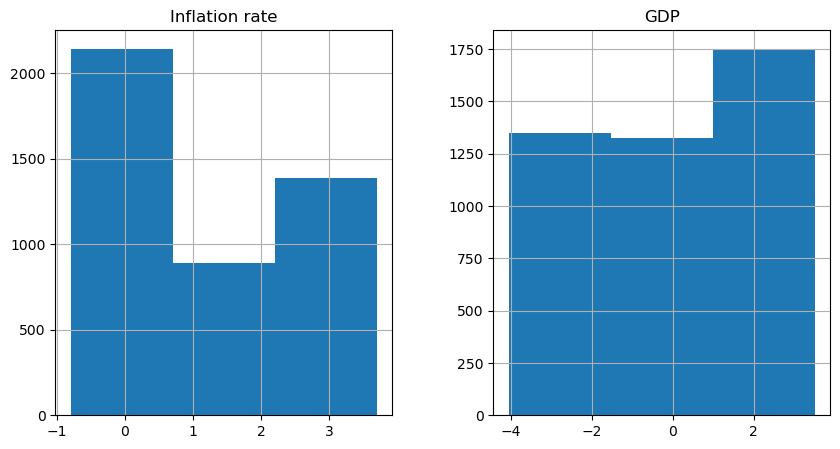

```python
#TODO: subplots for Inflation Rate & GDP
# st_drp[['Inflation rate', 'GDP']].hist(figsize=(10, 5))
st_drp[['Inflation rate', 'GDP']].hist(bins=3, figsize=(10, 5))
plt.show()
```

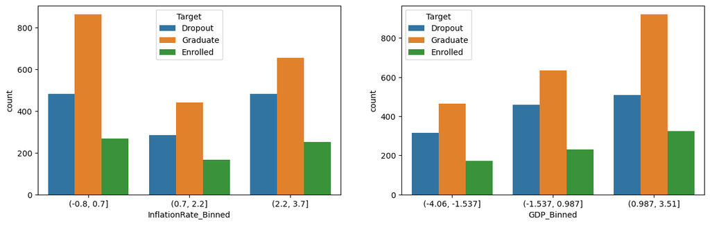

```python
import numpy as np
hist_values_GDP, bin_edges_GDP = np.histogram(st_drp['GDP'], bins=3)
hist_values_inflation, bin_edges_inflation = np.histogram(st_drp['Inflation rate'], bins=3)

# bin_edges_GDP.tolist()
# bin_edges_inflation.tolist()

binned_data_GDP = pd.cut(st_drp['GDP'], bin_edges_GDP.tolist())
binned_data_Inflation_Rate = pd.cut(st_drp['Inflation rate'], bin_edges_inflation.tolist())

binned_df = st_drp.copy()
binned_df['GDP_Binned'] = binned_data_GDP
binned_df['InflationRate_Binned'] = binned_data_Inflation_Rate

bin_features = ['InflationRate_Binned', 'GDP_Binned']
fig = plt.subplots(figsize=(15, 30))
for i, j in enumerate(bin_features):
    plt.subplot(4, 2, i+1)
    plt.subplots_adjust(hspace=1.0)
    sns.countplot(x=j, data=binned_df, hue='Target')
```

**Analysis**  
To see the relationship of continuous variables such as GDP and Inflation Rate to the categorical target it might be useful to bin them for visual purposes. Based on the Histograms it seems that roughly three bins for both variables seem to be good. These bins could be interpreted as "Low", "Moderate", and "High" Inflation Rate or GDP respectively.

It can be seen from the count plots that a lots of students tend to drop when Inflation rate is very low or very high but not as much when it is moderate. Interestingly more students tend to drop during moderate and high GDP compared to lower GDP, these features could perhaps be looked at later in a cluster analysis to identify some pattern.

Most students tend to graduate or stay enrolled when inflation is very low and GDP is very high.

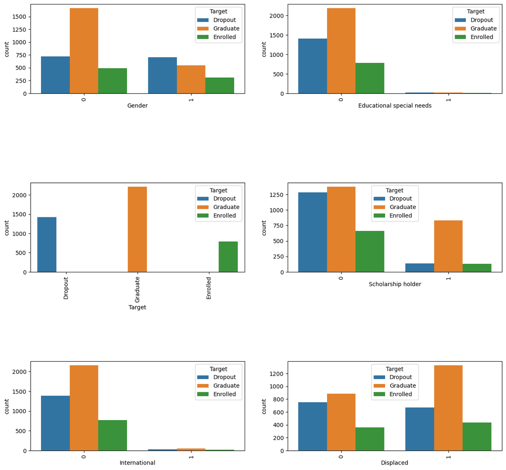

```python
features = ['Gender','Educational special needs','Target', 'Scholarship holder', 'International','Displaced']

fig = plt.subplots(figsize=(15, 20))
for i, j in enumerate(features):
    plt.subplot(4, 2, i+1)
    plt.subplots_adjust(hspace=1.0)
    sns.countplot(x=j, data=st_drp, hue='Target')
    plt.xticks(rotation=90)
```

**Analysis**

### Cluster Analysis

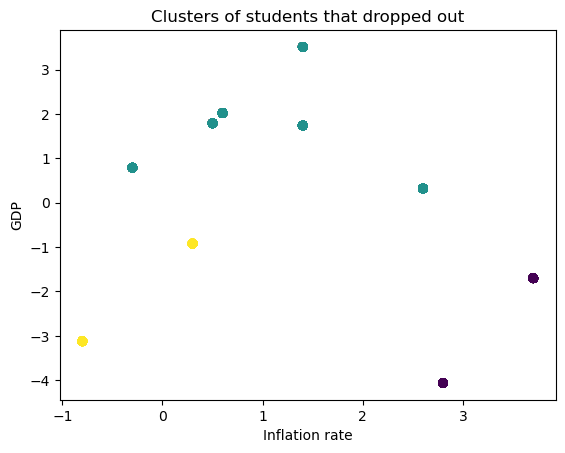

```python
from sklearn.cluster import KMeans

# Data Filtering
target_vals = ['Dropout']
clustering_features = ['Inflation rate', 'GDP']

target_st = st_drp[clustering_features][st_drp['Target'].isin(target_vals)]

kmeans = KMeans(n_clusters=3, random_state=0).fit(target_st)

target_st['label'] = kmeans.labels_

plt.scatter(target_st[clustering_features[0]], target_st[clustering_features[1]], c=target_st['label'])
plt.xlabel(clustering_features[0])
plt.ylabel(clustering_features[1])
plt.title('Clusters of students that dropped out')
plt.show()
```

**Analysis**  
A cluster analysis seems to indicate that students who drop out ted to either:

- live in a region with low GDP and high inflation rate
- live in a region with low GDP and low inflation rate
- live in a region with high GDP and low to moderate inflation rate (possibe bad match)

### Creating Dummy Variables

```python
# Creating Dummy Variable for Target
# Dummy Variable is DroputStatus, 1 if dropped out 0 if not (i.e. 0 if graduate or enrolled)

st_drp_encoded = st_drp.copy()

encoding = {'Dropout': 1, 'Graduate': 0, 'Enrolled': 0}

st_drp_encoded['Dropout'] = st_drp_encoded['Target'].map(encoding)
st_drp_encoded = st_drp_encoded.drop('Target', axis=1)

st_drp_encoded.head()
```

|  | Marital status | Application mode | Application order | Course | Daytime/evening attendance | Previous qualification | Nationality | Mother's qualification | Father's qualification | Mother's occupation | ... | Curricular units 2nd sem (credited) | Curricular units 2nd sem (enrolled) | Curricular units 2nd sem (evaluations) | Curricular units 2nd sem (approved) | Curricular units 2nd sem (grade) | Curricular units 2nd sem (without evaluations) | Unemployment rate | Inflation rate | GDP | Dropout |
| --- | --- | --- | --- | --- | --- | --- | --- | --- | --- | --- | --- | --- | --- | --- | --- | --- | --- | --- | --- | --- | --- |
| 0 | 1 | 8 | 5 | 2 | 1 | 1 | 1 | 13 | 10 | 6 | ... | 0 | 0 | 0 | 0 | 0.000000 | 0 | 10.8 | 1.4 | 1.74 | 1 |
| 1 | 1 | 6 | 1 | 11 | 1 | 1 | 1 | 1 | 3 | 4 | ... | 0 | 6 | 6 | 6 | 13.666667 | 0 | 13.9 | -0.3 | 0.79 | 0 |
| 2 | 1 | 1 | 5 | 5 | 1 | 1 | 1 | 22 | 27 | 10 | ... | 0 | 6 | 0 | 0 | 0.000000 | 0 | 10.8 | 1.4 | 1.74 | 1 |
| 3 | 1 | 8 | 2 | 15 | 1 | 1 | 1 | 23 | 27 | 6 | ... | 0 | 6 | 10 | 5 | 12.400000 | 0 | 9.4 | -0.8 | -3.12 | 0 |
| 4 | 2 | 12 | 1 | 3 | 0 | 1 | 1 | 22 | 28 | 10 | ... | 0 | 6 | 6 | 6 | 13.000000 | 0 | 13.9 | -0.3 | 0.79 | 0 |

5 rows × 35 columns

```python
# dataframe of features to use for model
student_dropout_df = st_drp_encoded[['Gender','Educational special needs', 'Scholarship holder', 'International','Displaced', 'Dropout']]
student_dropout_df.info()
```

```
<class 'pandas.core.frame.DataFrame'>
RangeIndex: 4424 entries, 0 to 4423
Data columns (total 6 columns):
 #   Column                     Non-Null Count  Dtype
---  ------                     --------------  -----
 0   Gender                     4424 non-null   int64
 1   Educational special needs  4424 non-null   int64
 2   Scholarship holder         4424 non-null   int64
 3   International              4424 non-null   int64
 4   Displaced                  4424 non-null   int64
 5   Dropout                    4424 non-null   int64
dtypes: int64(6)
memory usage: 207.5 KB
```

### Fitting a Model

Splitting data into training and testing

```python
from sklearn.model_selection import train_test_split

X = student_dropout_df.drop(['Dropout'], axis=1)
y = student_dropout_df['Dropout']

# 70% Training and 30% Testing
X_train, X_test, y_train, y_test = train_test_split(X, y, test_size=0.3, random_state=42)
```

```python
# from sklearn import utils
# print(utils.multiclass.type_of_target(y))

student_dropout_df['Dropout']
```

```
0       1
1       0
2       1
3       0
4       0
       ..
4419    0
4420    1
4421    1
4422    0
4423    0
Name: Dropout, Length: 4424, dtype: int64
```

```python
print( X_train.shape, y_train.shape)
print (X_test.shape, y_test.shape)
```

```
(3096, 5) (3096,)
(1328, 5) (1328,)
```

Fitting a model

```python
from sklearn.linear_model import LogisticRegression

dropout_logRegr = LogisticRegression()
dropout_logRegr.fit(X_train, y_train)

predictions = dropout_logRegr.predict(X_test)

print("Score:", dropout_logRegr.score(X_test, y_test))
```

```
Score: 0.6965361445783133
```

### K Fold Cross Validation

```python
from sklearn.model_selection import KFold
from sklearn.model_selection import cross_val_score
import numpy as np

model = LogisticRegression()
kfold = KFold(n_splits=10, random_state=None, shuffle=False)
scores = cross_val_score(model, X, y, cv=kfold)

print("Cross-Validation Scores:", scores)
print("\nMean CV Score:", np.mean(scores))
```

```
Cross-Validation Scores: [0.72911964 0.65011287 0.69977427 0.67268623 0.72171946 0.64027149
 0.71040724 0.68552036 0.68099548 0.70588235]

Mean CV Score: 0.6896489382347835
```